# Reproducible Research 2021: Live analysis of betting odds for tennis matches

Rafał Rysiejko

Michał Sałach

May 2021

# Best bet prediction

## Introduction

In our project, we search for the most profitable bets to make on the tennis matches for a given moment. We consider seven popular Polish bookmakers whose betting odds are reported on an ongoing basis on flashscore.pl/tennis. We are interested in the results only (who wins) and only in the ongoing or scheduled matches for a given day. It may be safely assumed that each match will have a winner. It is also pretty always the case that for each match, there is a favorite of the bookmakers (the bookmakers do not have to be unanimous, or it may in principle happen that the odds for both players are the same - this does not cause a problem for our analysis). A favorite of a bookmaker in a given match is the player for whom offers are lower (closer to 1). There is also a favorite of a client of the bookmaker - this is the player whose win would grant the client a profit.

Given that in reality, offers for both players are greater than 1, a client does not have to bet all their money on a favorite to achieve some profit. The remaining amount of money the client would bet on a non-favorite as a form of insurance in the case of misfortune (favorite loses). A no-risk bet is, therefore, a bet in which there is a proportion of money to bet, such that a client of a bookmaker has a profit also when their favorite loses. For example, in betting, odds for a player A (the bookmaker’s favorite) are 1.5, and for a player, B is 3.5, a client may bet 700 PLN on a player A and 300 PLN on a player B, granting a win of 1050 PLN (5% profit) in both cases. Such bets rather do not happen in reality, but the project aims to find the offers that come the closest to this, for any moment in time.

Our analysis is looking for the best bets to make from two angles: minimizing loss and maximizing return. Hence, we use two notions of profitability: In the first sense, we are interested in bets that would give a client minimal loss, having fixed on some level expected to return in the case of the client’s favorite win. In the second sense, we are looking for bets that would give a maximal client return in their favorite’s win, having fixed on some level the loss in the adverse case. The report will therefore accept 3 meta-prameters: *money* (money to bet, defaul 1000 PLN), *expected_return* (default 0.1) and *adverse_return* (default -0.2).

### Summary statistics

|  | eFortuna | STS | Betclick | Betfan | Lvbet | Pzbuk | Totolotek |
| --- | --- | --- | --- | --- | --- | --- | --- |
| Number of bets | 66.000000 | 65.000000 | 53.000000 | 59.000000 | 58.00000 | 44.000000 | 27.000000 |
| Average offer | 2.608939 | 2.609692 | 2.542076 | 2.660848 | 2.76431 | 2.617046 | 2.479259 |

| Matches count | Women matches | Men matches | Number of bets | Live matches | Planned matches |
| --- | --- | --- | --- | --- | --- |
| 70 | 28 | 42 | 67 | 10 | 60 |

### Best bet in case the favourite loses

Having 1000 PLN, the best bet to do right now in order to have maximum-20% return in the case of a favorite loss and maximal return in the case of the favorite win is to bet 761.9PLN on Oksana Selekhmeteva (Rus, ATP ranking: 540) on [STS](https://www.sts.pl/) (betting odds: 1.05, expected return: 2023.81 PLN, that is 102.38%) and 238.1 PLN on Emilie Lindh (Gbr, ATP ranking: 696) on [Pzbuk](https://www.pzbuk.pl/pl) (betting odds: 8.5) in ITF Womens - Single: W15 Santa Margarita de Montbui (Spain), hard courts - 1/8 final (starting 27-05-2021 15:00:00)

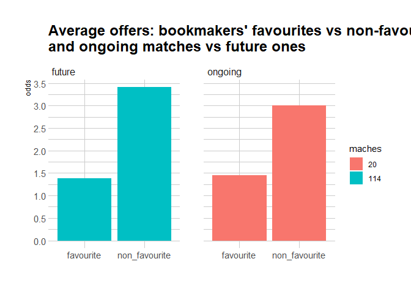

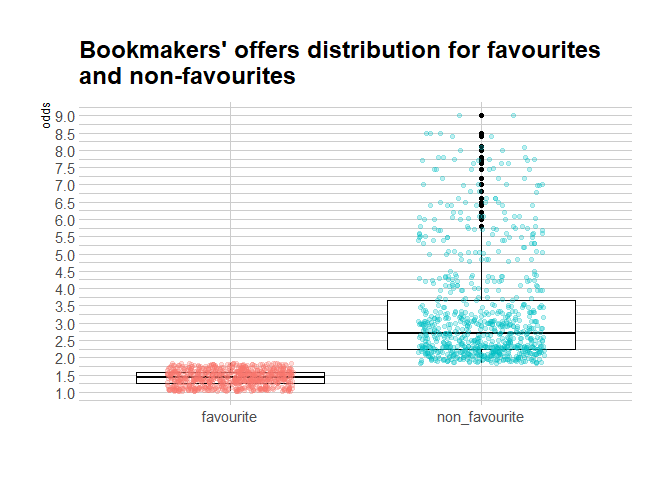

### Top 3 bets for each bookmaker

**eFortuna**

*Best return in adverse scenario given -20% return in the case of the favorite’s win*

1. Bet 372.88 PLN for Yoshihito Nishioka and 627.12 PLN for Sebastian Korda in ATP - Single: Parma (Italy), grass courts - quarter finals (starting 27-05-2021 15:00:00) with an expected return of 959.49
2. Bet 366.67 PLN for Roberto Carballes Baena and 633.33 PLN for Federico Delbonis in ATP - Single: Belgrade 2 (Serbia), grass courts - quarter finals (starting 27-05-2021 15:00:00) with an expected return of 950
3. Bet 0 PLN for Pedro Araujo and 1000 PLN for Gastao Elias in CHALLENGER Mens - Single: Oeiras 4 (Portugal), grass courts - 1/8 final (starting 27-05-2021 14:00:00) with an expected return of 927.14

*Best return in maximum return scenario given 10% expected return in the case of the favorite’s win*

1. Bet 776.7 PLN for Miharu Imanishi and 223.3 PLN for Ines Bekrar in ITF Womens - Single: W15 Monastir 14 (Tunisia), hard courts - 1/8 final (starting 27-05-2021 15:00:00) with an expected return of 2009.71
2. Bet 727.27 PLN for Gastao Elias and 272.73 PLN for Pedro Araujoin CHALLENGER Mens - Single: Oeiras 4 (Portugal), grass courts - 1/8 final (starting 27-05-2021 15:00:00) with an expected return of 1909.09
3. Bet 754.72 PLN for Emma Davis / Maria Paulina Perez Garcia and 245.28 PLN for Ralina Kalimullina / Kuliczkowa Jelizawieta Morozova in ITF Womens - DEBEL: W15 Monastir (Tunisia), hard courts - quarter finals (starting 27-05-2021 14:00:00) with an expected return of 1900.94

**STS**

*Best return in adverse scenario given -20% return in the case of the favorite’s win*

1. Bet 392.86 PLN for Max Purcell / Luke Saville and 607.14 PLN for Simone Bolelli / Maximo Gonzalez in ATP - DEBEL: Parma (Italy), grass courts - quarter finals (starting 27-05-2021 15:00:00) with an expected return of 922.86
2. Bet 169.23 PLN for Vasilios Caripi / Kelsey Stevenson and 830.77 PLN for Runhao Hua / Ze Zhang in ITF Mens - DEBEL: M15 Heraklion 8 (Greece), hard courts - quarter finals (starting 27-05-2021 15:00:00) with an expected return of 913.85
3. Bet 0 PLN for Rrezart Cungu and 1000 PLN for Francesco Forti in ITF Mens - Single: M25 Kiseljak (Bośnia i Hercegowina), grass courts - 1/8 final (starting 27-05-2021 14:00:00) with an expected return of 904.84

*Best return in maximum return scenario given 10% expected return in the case of the favorite’s win*

1. Bet 761.9 PLN for Oksana Selekhmeteva and 238.1 PLN for Emilie Lindh in ITF Womens - Single: W15 Santa Margarita de Montbui (Spain), hard courts - 1/8 final (starting 27-05-2021 15:00:00) with an expected return of 2023.81
2. Bet 776.7 PLN for Miharu Imanishi and 223.3 PLN for Ines Bekrarin ITF Womens - Single: W15 Monastir 14 (Tunisia), hard courts - 1/8 final (starting 27-05-2021 15:00:00) with an expected return of 2009.71
3. Bet 754.72 PLN for Emma Davis / Maria Paulina Perez Garcia and 245.28 PLN for Ralina Kalimullina / Kuliczkowa Jelizawieta Morozova in ITF Womens - DEBEL: W15 Monastir (Tunisia), hard courts - quarter finals (starting 27-05-2021 14:00:00) with an expected return of 1900.94

**Betclick**

*Best return in adverse scenario given -20% return in the case of the favorite’s win*

1. Bet 372.88 PLN for Yoshihito Nishioka and 627.12 PLN for Sebastian Korda in ATP - Single: Parma (Italy), grass courts - quarter finals (starting 27-05-2021 15:00:00) with an expected return of 959.49
2. Bet 179.1 PLN for Jaqueline Adina Cristian and 820.9 PLN for Anhelina Kalinina in WTA - Single: French Open (France) - qualifications, grass courts - final (starting 27-05-2021 15:00:00) with an expected return of 946.93
3. Bet 191.18 PLN for Andrej Martin and 808.82 PLN for Dusan Lajovic in ATP - Single: Belgrade 2 (Serbia), grass courts - quarter finals (starting 27-05-2021 14:00:00) with an expected return of 926.38

*Best return in maximum return scenario given 10% expected return in the case of the favorite’s win*

1. Bet 754.72 PLN for Emma Davis / Maria Paulina Perez Garcia and 245.28 PLN for Ralina Kalimullina / Kuliczkowa Jelizawieta Morozova in ITF Womens - DEBEL: W15 Monastir (Tunisia), hard courts - quarter finals (starting 27-05-2021 15:00:00) with an expected return of 1900.94
2. Bet 740.74 PLN for Luca Castelnuovo / Yannik Steinegger and 259.26 PLN for Jonas Maier / Simonas Zukauskasin ITF Mens - DEBEL: M15 Kouvola (Finland), hard courts - quarter finals (starting 27-05-2021 15:00:00) with an expected return of 1814.81
3. Bet 835.05 PLN for Alexander Cozbinov / Francesco Vilardo and 164.95 PLN for August Ehrnrooth / Karl Kiur Saar in ITF Mens - DEBEL: M15 Kouvola (Finland), hard courts - quarter finals (starting 27-05-2021 14:00:00) with an expected return of 1533.76

**Betfan**

*Best return in adverse scenario given -20% return in the case of the favorite’s win*

1. Bet 366.67 PLN for Roberto Carballes Baena and 633.33 PLN for Federico Delbonis in ATP - Single: Belgrade 2 (Serbia), grass courts - quarter finals (starting 27-05-2021 15:00:00) with an expected return of 950
2. Bet 179.1 PLN for Jaqueline Adina Cristian and 820.9 PLN for Anhelina Kalinina in WTA - Single: French Open (France) - qualifications, grass courts - final (starting 27-05-2021 15:00:00) with an expected return of 946.93
3. Bet 0 PLN for Pedro Araujo and 1000 PLN for Gastao Elias in CHALLENGER Mens - Single: Oeiras 4 (Portugal), grass courts - 1/8 final (starting 27-05-2021 14:00:00) with an expected return of 927.14

*Best return in maximum return scenario given 10% expected return in the case of the favorite’s win*

1. Bet 761.9 PLN for Oksana Selekhmeteva and 238.1 PLN for Emilie Lindh in ITF Womens - Single: W15 Santa Margarita de Montbui (Spain), hard courts - 1/8 final (starting 27-05-2021 15:00:00) with an expected return of 2023.81
2. Bet 776.7 PLN for Miharu Imanishi and 223.3 PLN for Ines Bekrarin ITF Womens - Single: W15 Monastir 14 (Tunisia), hard courts - 1/8 final (starting 27-05-2021 15:00:00) with an expected return of 2009.71
3. Bet 727.27 PLN for Gastao Elias and 272.73 PLN for Pedro Araujo in CHALLENGER Mens - Single: Oeiras 4 (Portugal), grass courts - 1/8 final (starting 27-05-2021 14:00:00) with an expected return of 1909.09

**Pzbuk**

*Best return in adverse scenario given -20% return in the case of the favorite’s win*

1. Bet 318.84 PLN for Andrej Martin and 681.16 PLN for Dusan Lajovic in ATP - Single: Belgrade 2 (Serbia), grass courts - quarter finals (starting 27-05-2021 15:00:00) with an expected return of 926.38
2. Bet 276.32 PLN for Max Purcell / Luke Saville and 723.68 PLN for Simone Bolelli / Maximo Gonzalez in ATP - DEBEL: Parma (Italy), grass courts - quarter finals (starting 27-05-2021 15:00:00) with an expected return of 922.86
3. Bet 276.32 PLN for Max Purcell / Luke Saville and 723.68 PLN for Simone Bolelli / Maximo Gonzalez in ATP - DEBEL: Parma (Italy), grass courts - quarter finals (starting 27-05-2021 14:00:00) with an expected return of 922.86

*Best return in maximum return scenario given 10% expected return in the case of the favorite’s win*

1. Bet 761.9 PLN for Oksana Selekhmeteva and 238.1 PLN for Emilie Lindh in ITF Womens - Single: W15 Santa Margarita de Montbui (Spain), hard courts - 1/8 final (starting 27-05-2021 15:00:00) with an expected return of 2023.81
2. Bet 761.9 PLN for Oksana Selekhmeteva and 238.1 PLN for Emilie Lindhin ITF Womens - Single: W15 Santa Margarita de Montbui (Spain), hard courts - 1/8 final (starting 27-05-2021 15:00:00) with an expected return of 2023.81
3. Bet 776.7 PLN for Miharu Imanishi and 223.3 PLN for Ines Bekrar in ITF Womens - Single: W15 Monastir 14 (Tunisia), hard courts - 1/8 final (starting 27-05-2021 14:00:00) with an expected return of 2009.71

**Lvbet**

*Best return in adverse scenario given -20% return in the case of the favorite’s win*

1. Bet 207.55 PLN for Mariam Dalakishvili / Anastasiya Poplavska and 792.45 PLN for Martyna Kubka / Zhibek Kulambayeva in ITF Womens - DEBEL: W15 Shymkent 5 (Kazakhstan), grass courts - quarter finals (starting 27-05-2021 15:00:00) with an expected return of 919.25
2. Bet 105.69 PLN for Nicole Gadient / Valentina Ryser and 894.31 PLN for Celia Cervino Ruiz / Olivia Nicholls in ITF Womens - DEBEL: W15 Santa Margarita de Montbui (Spain), hard courts - semi-finals (starting 27-05-2021 15:00:00) with an expected return of 918.97
3. Bet 502.28 PLN for Arthur Bouquier and 497.72 PLN for Roy Smith in ITF Mens - Single: M15 Monastir 14 (Tunisia), hard courts - 1/8 final (starting 27-05-2021 14:00:00) with an expected return of 910.82

*Best return in maximum return scenario given 10% expected return in the case of the favorite’s win*

1. Bet 776.7 PLN for Miharu Imanishi and 223.3 PLN for Ines Bekrar in ITF Womens - Single: W15 Monastir 14 (Tunisia), hard courts - 1/8 final (starting 27-05-2021 15:00:00) with an expected return of 2009.71
2. Bet 740.74 PLN for Luca Castelnuovo / Yannik Steinegger and 259.26 PLN for Jonas Maier / Simonas Zukauskasin ITF Mens - DEBEL: M15 Kouvola (Finland), hard courts - quarter finals (starting 27-05-2021 15:00:00) with an expected return of 1814.81
3. Bet 740.74 PLN for Luca Castelnuovo / Yannik Steinegger and 259.26 PLN for Jonas Maier / Simonas Zukauskas in ITF Mens - DEBEL: M15 Kouvola (Finland), hard courts - quarter finals (starting 27-05-2021 14:00:00) with an expected return of 1814.81

**Totolotek**

*Best return in adverse scenario given -20% return in the case of the favorite’s win*

1. Bet 157.14 PLN for Pedro Araujo and 842.86 PLN for Gastao Elias in CHALLENGER Mens - Single: Oeiras 4 (Portugal), grass courts - 1/8 final (starting 27-05-2021 15:00:00) with an expected return of 927.14
2. Bet 157.14 PLN for Pedro Araujo and 842.86 PLN for Gastao Elias in CHALLENGER Mens - Single: Oeiras 4 (Portugal), grass courts - 1/8 final (starting 27-05-2021 15:00:00) with an expected return of 927.14
3. Bet 207.55 PLN for Mariam Dalakishvili / Anastasiya Poplavska and 792.45 PLN for Martyna Kubka / Zhibek Kulambayeva in ITF Womens - DEBEL: W15 Shymkent 5 (Kazakhstan), grass courts - quarter finals (starting 27-05-2021 14:00:00) with an expected return of 919.25

*Best return in maximum return scenario given 10% expected return in the case of the favorite’s win*

1. Bet 727.27 PLN for Gastao Elias and 272.73 PLN for Pedro Araujo in CHALLENGER Mens - Single: Oeiras 4 (Portugal), grass courts - 1/8 final (starting 27-05-2021 15:00:00) with an expected return of 1909.09
2. Bet 727.27 PLN for Gastao Elias and 272.73 PLN for Pedro Araujoin CHALLENGER Mens - Single: Oeiras 4 (Portugal), grass courts - 1/8 final (starting 27-05-2021 15:00:00) with an expected return of 1909.09
3. Bet 689.66 PLN for Martyna Kubka / Zhibek Kulambayeva and 310.34 PLN for Mariam Dalakishvili / Anastasiya Poplavska in ITF Womens - DEBEL: W15 Shymkent 5 (Kazakhstan), grass courts - quarter finals (starting 27-05-2021 14:00:00) with an expected return of 1644.83

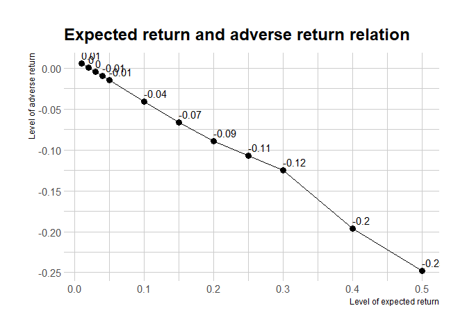

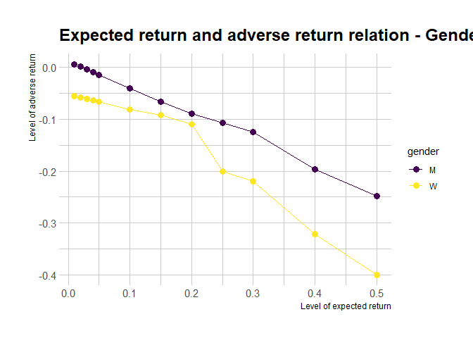

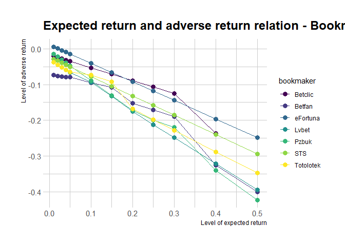

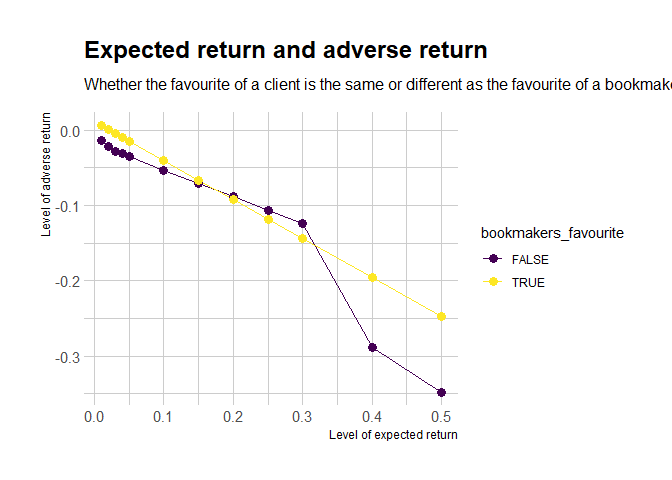

**Disclaimer**

*Please note, that online betting is a gambling entertainment vehicle, and that it carries with it a certain degree of financial risk. Players should be aware of this risk, and govern themselves accordingly.*